# Exercice N°1

```python
import numpy as np
import matplotlib.pyplot as plt
```

### 1. Formalize the problem as a Markov decision process (MDP).

- Markov Decision Process (MDP) is a mathematical framework for formalizing RL problem by modeling the interaction between an agent and its environment.
- Formally, A Markov Decision Process is a tuple,<S,A,P,R,γ> :
  - S: state space
  - A: action space
  - R: provide immediate reward received after taking action a in state s
  - P(s′∣s,a): Define the probability of moving from one state **s** to another **s'**, given a specific action **a**
  - $γ \in [0.1]$ : determines the importance of future rewards compared to immediate rewards

For the 3x3 grid world, the MDP is defined as follows

- state sapce : The state space consists of all possible agent positions in the 3x3 grid.
  - $S=\{(i,j); i, j ∈ \{1, 2,3\} \}$
  - $S= \{(1,1), (1,2), (1,3), (2,1), (2,2), (2,3), (3,1), (3,2), (3,3)\}$
- action space :
  - $A=\{Up, Down, Left, Right\} = \{0,1,2,3\}$
  - $A=\{(\Delta i,\Delta j ) ; \Delta i, \Delta j ∈\{-1, 0, 1\} and |\Delta i|+|\Delta j|=1 \}$
  - $A=\{(-1,0), (+1,0), (0,-1), (0,+1)\}$
- Reward function : is function of state and action
  - R(s, a) = -1 if the action a is non-permitted from state s
  - R(s, a) = r, where r is the value given in the reward table
- Transition Probability Function:
  - P(s' | s, a) = 1 if s' is adjacent to s in the direction of action a
  - P(s' | s, a) = 1 if a is non-permitted action and s' = s
  - P(s' | s, a) = 0 otherwise
- $γ=0.7$

#### 2. Determine the size of the state and action spaces

- card(A)=4
- card(S)=9

#### 3. At a given time step t, suppose the agent is in one of the following states and selects one of the following actions. What are the possible rewards and subsequent states for the three policies?

[output not shown]

[output not shown]

#### 4. Is this problem a continuing or episodic task? Justify your answer.

This problem is a continuing task because there is no terminal state or condition that ends the agent-environment interaction.

#### 5. How to transform this problem into an episodic task?

To transform this into an episodic task, we can define a terminal state or a termination condition (such as a maximum number of steps per episode).

#### 6. Initialize the Policies π1, π 2, and π3 with their respective action probabilities

[output not shown]

```python
# global variable
nb_rows=3
nb_cols=3
nb_actions=4
shapePolicy=(nb_rows, nb_cols,nb_actions)
shapeValue=(nb_rows, nb_cols)
gamma=0.7
episode_length=20
nb_episodes=1000
```

```python
# Policy: define the probability of taking each action in each state

# action = [up, down, left, right] = [0,1,2,3]

policy1=np.array([
    [[0., 1., 0., 0.], [0., 1., 0., 0.], [0., 1., 0., 0.]],
    [[0., 1., 0., 0.], [0., 1., 0., 0.], [0., 1., 0., 0.]],
    [[0., 0., 0., 1.], [0., 0., 0., 1.], [0., 0., 0., 1.]],
    ])

policy2=np.array([
    [[0., 0.5, 0., 0.5], [0., 1., 0., 0.], [0., 0.5, 0.5, 0.]],
    [[0., 0., 0., 1.], [0.25, 0.25, 0.25, 0.25], [0., 0., 1., 0.]],
    [[0.5, 0., 0., 0.5], [1., 0., 0., 0.], [0.5, 0., 0.5, 0.]],
    ])

policy3=np.full(shapePolicy, 0.25)
# policy3=np.array([
#     [[0.25, 0.25, 0.25, 0.25], [0.25, 0.25, 0.25, 0.25], [0.25, 0.25, 0.25, 0.25]],
#     [[0.25, 0.25, 0.25, 0.25], [0.25, 0.25, 0.25, 0.25], [0.25, 0.25, 0.25, 0.25]],
#     [[0.25, 0.25, 0.25, 0.25], [0.25, 0.25, 0.25, 0.25], [0.25, 0.25, 0.25, 0.25]],
#     ])

#policy1[(1,1)]
policy1[(1,1)][0]
```

```
0.0
```

#### 7. Define the reward function that assigns a scalar value to each state-action pair

```python
# reward function R(s,a) is presented as 3D array (sate_row, sate_col, action_num)
# action = [up, down, left, right] = [0,1,2,3]
reward_function=np.array([
    [[-1., 2/3, -1., 1.], [-1., 2., 1/2, 3/2], [-1., 5/2, 1/2, -1.]],
    [[1/3, 3/2, -1., 4/3.], [1/4, 3., 1/3, 3/2], [1/4, 7/2, -1., 1.]],
    [[1/2, -1., -1., 3/2], [4/5, -1., 1., 3.], [1/2, -1., 4/5, -1.]],
    ])

#reward_function[(2,1)][3]
```

#### 8. Define the state transition function that returns the next state based on the current state and the executed action.

```python
# action = [up, down, left, right] = [0,1,2,3]
action_space=[(-1,0), (1,0), (0,-1), (0,1)]
action_space
```

```
[(-1, 0), (1, 0), (0, -1), (0, 1)]
```

```python
def getNextState(state:tuple, action_num:int):
    action=action_space[action_num]
    # if action == 0:
    #     nxtState=(state[0]-1,state[1])
    # elif action== 1:
    #     nxtState=(state[0]+1,state[1])
    # elif action== 2:
    #     nxtState=(state[0],state[1]-1)
    # else:
    #     nxtState=(state[0],state[1]+1)
    nxtState=(state[0]+action[0],state[1]+action[1])

    # check if the next state legal
    if (nxtState[0]>=0 and nxtState[0]<=2 and nxtState[1]>=0 and nxtState[1]<=2):
        return nxtState
    else:
        return state

getNextState((0,0), 1)
```

```
(1, 0)
```

#### 9. Define select_action() function that selects an action based on the current state and a given policy

```python
def select_action(state, policy)-> int:
    prob_a=policy[state]
    action=np.random.choice(nb_actions,p=prob_a)
    return action
```

#### 10. Define the get_trajectory() function that simulates a single episode by following the specified policy. This function returns a trajectory of sequential experiences, where each experience is represented as a tuple containing the (state, action, reward)

```python
def get_trajectory(policy):
    state=(0,0) #start_state
    trajectory=[]
    for i in range(episode_length):
        action =select_action(state, policy)
        reward=reward_function[state][action]
        sar=[state,action,reward]
        trajectory.append(sar)
        state=getNextState(state, action)
    return trajectory
```

#### 11. Define the get_returns() function that returns the discounted returns for each state in the given trajectory

```python
def get_returns(returns,trajectory):
    G = 0
    for t, sar in enumerate(reversed(trajectory)):
        s, a, r = sar
        G= r + gamma * G
        if s in returns:
            returns[s].append(G)
        else:
            returns[s] = [G]
    return returns
```

#### 12. Given that the Monte Carlo method computes the value function of each policy by averaging the discounted returns for each state generated from a set of simulated episodes. Compute the value function of each policy

```python
def monte_carlo_policy_evaluation(policy,nb_episodes):
    #initialization of the value function
    value_function=np.zeros(shapeValue)
    returns={}
    for i in range(nb_episodes):
        trajectory= get_trajectory(policy)
        returns = get_returns(returns, trajectory)

    for i in range(nb_rows):
        for j in range (nb_cols):
            if (i,j) in returns:
                value_function[(i,j)] = np.round(np.mean(returns[(i,j)]), 2)  # rounds the  mean two decimal places

    return value_function
```

```python
v1=monte_carlo_policy_evaluation(policy1,nb_episodes)
v2=monte_carlo_policy_evaluation(policy2,nb_episodes)
v3=monte_carlo_policy_evaluation(policy3,nb_episodes)
```

```python
def plot_function(v):
    plt.imshow(v, cmap='Greys')
    for i in range(nb_rows):
        for j in range (nb_cols):
            plt.text(j, i, f'{v[i, j]}', ha='center', va='center', color='r', fontsize=25)
    plt.xticks([]) # Hide the x-axis values
    plt.yticks([]) # Hide the y-axis values
    plt.show()
```

```
Value function of policy π1
```

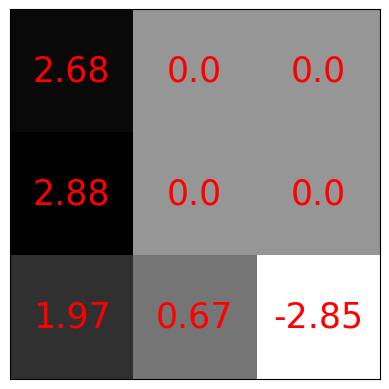

```
Value function of policy π2
```

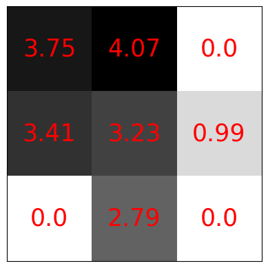

```
Value function of policy π3
```

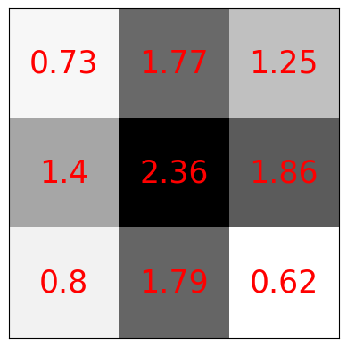

```python
print ("Value function of policy π1")
plot_function(v1)
print ("Value function of policy π2")
plot_function(v2)
print ("Value function of policy π3")
plot_function(v3)
```